# Midterm - Steve Cheney

2024-05-07

## Data inports

“143” = journal_1_.pone.0000216.s007 “159” = journal_1_.pone.0000216.s008

```r
library(readxl)
library(dplyr)
library(tidyr)
```

```r
library(ggplot2)
library(gridExtra)
library(stats)
library(rsample)
library("ALL")
# S3 / 143
s3_url <- "https://www.ncbi.nlm.nih.gov/pmc/articles/PMC1789144/bin/pone.0000216.s007.xls"
s3_file <- "table_s3_143.xls"
curl::curl_download(s3_url, s3_file)
s3_table <- read_excel(s3_file, range = "A4:U147")
# S4 / 159
s4_url <- "https://www.ncbi.nlm.nih.gov/pmc/articles/PMC1789144/bin/pone.0000216.s008.xls"
s4_file <- "table_s3_143.xls"
curl::curl_download(s4_url, s4_file)
s4_table <- read_excel(s4_file, range = "A4:U163")
rename_first_three_columns <- function(data_frame) {
  # Rename the first three columns
  names(data_frame)[1:3] <- c("refseq_id", "uniprot_swissprot", "protein_name")

  # Return the modified data frame
  return(data_frame)
}

s3_table <- rename_first_three_columns(s3_table)
s4_table <- rename_first_three_columns(s4_table)
```

```r
# Calculate the means for s3
s3_means <- s3_table %>%
  reframe(
    chimp_mrna = apply(s3_table[,4:9], 1, mean, na.rm = TRUE),
    human_mrna = apply(s3_table[,10:15], 1, mean, na.rm = TRUE),
    chimp_protein = apply(s3_table[,16:18], 1, mean, na.rm = TRUE),
    human_protein = apply(s3_table[,19:21], 1, mean, na.rm = TRUE)
  )
# Add the means to the s3 table
s3_table <- s3_table %>%
  mutate(
    chimp_mrna_mean = apply(s3_table[,4:9], 1, mean),
    human_mrna_mean = apply(s3_table[,10:15], 1, mean),
    chimp_protein_mean = apply(s3_table[,16:18], 1, mean),
    human_protein_mean = apply(s3_table[,19:21], 1, mean)
  )
# Calculate the means for s4
s4_means <- s4_table %>%
  reframe(
    chimp_mrna = apply(s4_table[,4:9], 1, mean, na.rm = TRUE),
    human_mrna = apply(s4_table[,10:15], 1, mean, na.rm = TRUE),
    chimp_protein = apply(s4_table[,16:18], 1, mean, na.rm = TRUE),
    human_protein = apply(s4_table[,19:21], 1, mean, na.rm = TRUE)
  )
# Add the means to the s4 table
s4_table <- s4_table %>%
  mutate(
    chimp_mrna_mean = apply(s4_table[,4:9], 1, mean),
    human_mrna_mean = apply(s4_table[,10:15], 1, mean),
    chimp_protein_mean = apply(s4_table[,16:18], 1, mean),
    human_protein_mean = apply(s4_table[,19:21], 1, mean)
  )
```

## Question 1

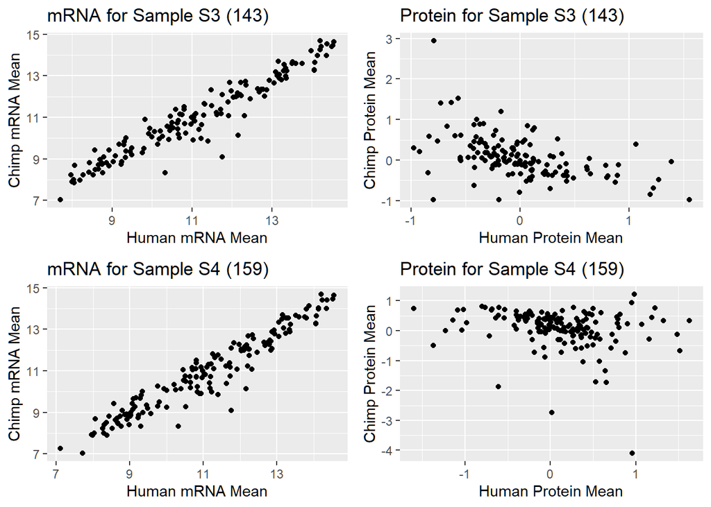

```r
# Plotting function
plot_data <- function(data, title_suffix) {
  p1 <- ggplot(data, aes(x = human_mrna_mean, y = chimp_mrna_mean)) +
    geom_point() +
    labs(title = paste("mRNA for", title_suffix),
         x = "Human mRNA Mean",
         y = "Chimp mRNA Mean")

  p2 <- ggplot(data, aes(x = human_protein_mean, y = chimp_protein_mean)) +
    geom_point() +
    labs(title = paste("Protein for", title_suffix),
         x = "Human Protein Mean",
         y = "Chimp Protein Mean")

  # Return plots as a list for grid
  list(mRNA = p1, Protein = p2)
}

# Generate plots for s3_table and s4_table
s3_plots <- plot_data(s3_table, "Sample S3 (143)")
s4_plots <- plot_data(s4_table, "Sample S4 (159)")

grid.arrange(s3_plots$mRNA, s3_plots$Protein, s4_plots$mRNA, s4_plots$Protein, ncol = 2)
```

In these plots you can see that there is a relatively strong correlation between the mRNA means in each sample for Human vs. Chimp and each hold to about the same overall means on the graph. There is less of a strong correlation between proteins, comparatively, and we start to potentially see the difference in the proteome where S3 has, in general, greater values for the Chimp Protein means in S3 compared to the S4 Chimp Protein means.

## Question 2

```r
# Calculate correlations with cor()
calculate_correlations <- function(data, sample_name) {
  # Calculating correlation between human and chimp mRNA means
  cor_mRNA <- cor(data$human_mrna_mean, data$chimp_mrna_mean, use = "complete.obs")

  # Calculating correlation between human and chimp protein means
  cor_protein <- cor(data$human_protein_mean, data$chimp_protein_mean, use = "complete.obs")

  cat(paste("\nCorrelation of mRNA between humans and chimps for", sample_name, ":", cor_mRNA))
  cat(paste("\nCorrelation of protein between humans and chimps for", sample_name, ":", cor_protein))
}

# Calculate correlations for s3_table
calculate_correlations(s3_table, "Sample S3")
```

```
##
## Correlation of mRNA between humans and chimps for Sample S3 : 0.957895612571867
## Correlation of protein between humans and chimps for Sample S3 : -0.50156744540713
```

```r
# Calculate correlations for s4_table
calculate_correlations(s4_table, "Sample S4")
```

```
##
## Correlation of mRNA between humans and chimps for Sample S4 : 0.957491810420527
## Correlation of protein between humans and chimps for Sample S4 : -0.221031638923096
```

We can see here that I was correct in saying that both the mRNA sample comparisons had a high correlation of about 0.957 each. I was also correct in saying that the protein sample comparisons had a low correlation (and both negative) where S3 is about -0.5 and S4 is about -0.221. S4’s protein means has the least amount of correlation among all sample comparisons.

## Question 3

```r
# Linear model fits

# s3
lm_mRNA_s3 <- lm(chimp_mrna_mean ~ human_mrna_mean, data = s3_table)
lm_protein_s3 <- lm(chimp_protein_mean ~ human_protein_mean, data = s3_table)

# s4
lm_mRNA_s4 <- lm(chimp_mrna_mean ~ human_mrna_mean, data = s4_table)
lm_protein_s4 <- lm(chimp_protein_mean ~ human_protein_mean, data = s4_table)

# Print summaries

cat("Summary of mRNA model for S3:\n")
```

```
## Summary of mRNA model for S3:
```

```r
print(summary(lm_mRNA_s3))
```

```
##
## Call:
## lm(formula = chimp_mrna_mean ~ human_mrna_mean, data = s3_table)
##
## Residuals:
##      Min       1Q   Median       3Q      Max
## -2.52471 -0.23440  0.04932  0.31545  1.12997
##
## Coefficients:
##                 Estimate Std. Error t value Pr(>|t|)
## (Intercept)      0.36426    0.27281   1.335    0.184
## human_mrna_mean  0.95703    0.02416  39.616   <2e-16 ***
## ---
## Signif. codes:  0 '***' 0.001 '**' 0.01 '*' 0.05 '.' 0.1 ' ' 1
##
## Residual standard error: 0.5288 on 141 degrees of freedom
## Multiple R-squared:  0.9176, Adjusted R-squared:  0.917
## F-statistic:  1569 on 1 and 141 DF,  p-value: < 2.2e-16
```

```r
cat("\nSummary of protein model for S3:\n")
```

```
##
## Summary of protein model for S3:
```

```r
print(summary(lm_protein_s3))
```

```
##
## Call:
## lm(formula = chimp_protein_mean ~ human_protein_mean, data = s3_table)
##
## Residuals:
##      Min       1Q   Median       3Q      Max
## -1.49154 -0.23908 -0.05785  0.18980  2.43956
##
## Coefficients:
##                    Estimate Std. Error t value Pr(>|t|)
## (Intercept)         0.06423    0.03799   1.691   0.0931 .
## human_protein_mean -0.55960    0.08129  -6.884 1.76e-10 ***
## ---
## Signif. codes:  0 '***' 0.001 '**' 0.01 '*' 0.05 '.' 0.1 ' ' 1
##
## Residual standard error: 0.4542 on 141 degrees of freedom
## Multiple R-squared:  0.2516, Adjusted R-squared:  0.2463
## F-statistic: 47.39 on 1 and 141 DF,  p-value: 1.759e-10
```

```r
cat("----------------------------------------------\nSummary of mRNA model for S4:\n")
```

```
## ----------------------------------------------
## Summary of mRNA model for S4:
```

```r
print(summary(lm_mRNA_s4))
```

```
##
## Call:
## lm(formula = chimp_mrna_mean ~ human_mrna_mean, data = s4_table)
##
## Residuals:
##      Min       1Q   Median       3Q      Max
## -2.47042 -0.21210  0.08016  0.35535  0.95991
##
## Coefficients:
##                 Estimate Std. Error t value Pr(>|t|)
## (Intercept)      0.17901    0.26196   0.683    0.495
## human_mrna_mean  0.96816    0.02328  41.591   <2e-16 ***
## ---
## Signif. codes:  0 '***' 0.001 '**' 0.01 '*' 0.05 '.' 0.1 ' ' 1
##
## Residual standard error: 0.5352 on 157 degrees of freedom
## Multiple R-squared:  0.9168, Adjusted R-squared:  0.9163
## F-statistic:  1730 on 1 and 157 DF,  p-value: < 2.2e-16
```

```r
cat("\nSummary of protein model for S4:\n")
```

```
##
## Summary of protein model for S4:
```

```r
print(summary(lm_protein_s4))
```

```
##
## Call:
## lm(formula = chimp_protein_mean ~ human_protein_mean, data = s4_table)
##
## Residuals:
##     Min      1Q  Median      3Q     Max
## -3.9688 -0.1686  0.0992  0.3375  1.3666
##
## Coefficients:
##                    Estimate Std. Error t value Pr(>|t|)
## (Intercept)         0.10968    0.05069   2.164  0.03201 *
## human_protein_mean -0.25612    0.09019  -2.840  0.00511 **
## ---
## Signif. codes:  0 '***' 0.001 '**' 0.01 '*' 0.05 '.' 0.1 ' ' 1
##
## Residual standard error: 0.6263 on 157 degrees of freedom
## Multiple R-squared:  0.04885,    Adjusted R-squared:  0.0428
## F-statistic: 8.064 on 1 and 157 DF,  p-value: 0.005113
```

```r
# Plot diagnostics

par(mfrow = c(2, 2))

# Diagnostic plots for S3 mRNA model
cat("\nDiagnostics for mRNA model s3_table:\n")
```

```
##
## Diagnostics for mRNA model s3_table:
```

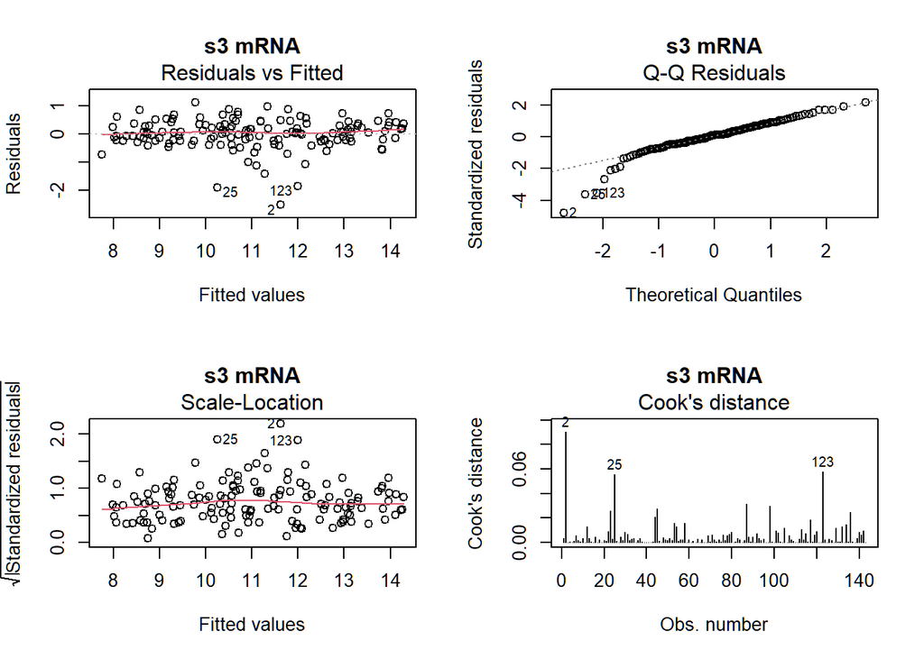

```r
plot(lm_mRNA_s3, which = 1:4, main = "s3 mRNA")
```

```r
# Diagnostic plots for S3 protein model
cat("\nDiagnostics for protein model s3_table:\n")
```

```
##
## Diagnostics for protein model s3_table:
```

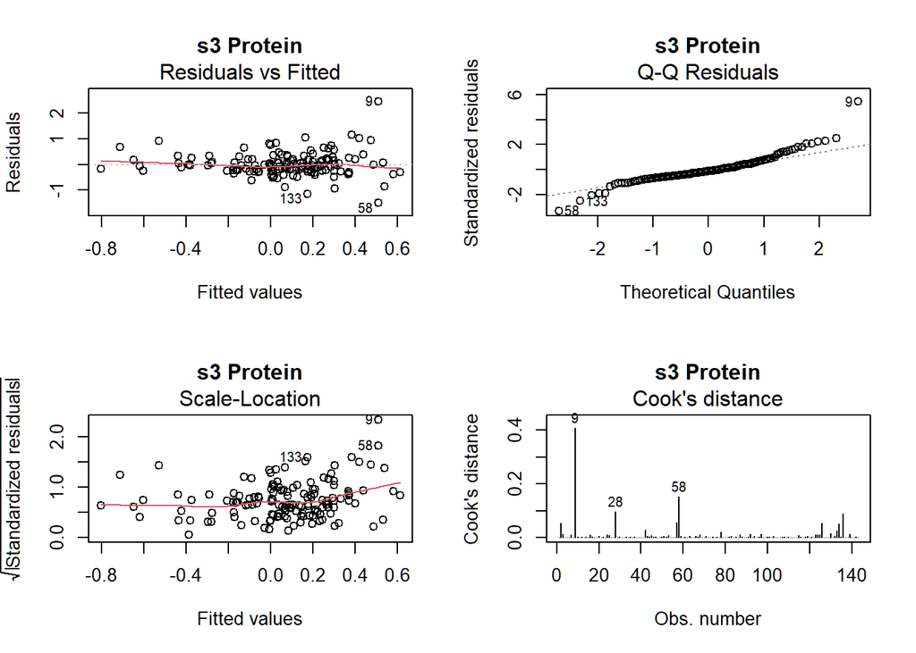

```r
plot(lm_protein_s3, which = 1:4, main = "s3 Protein")
```

```r
# Diagnostic plots for S4 mRNA model
cat("\nDiagnostics for mRNA model s4_table:\n")
```

```
##
## Diagnostics for mRNA model s4_table:
```

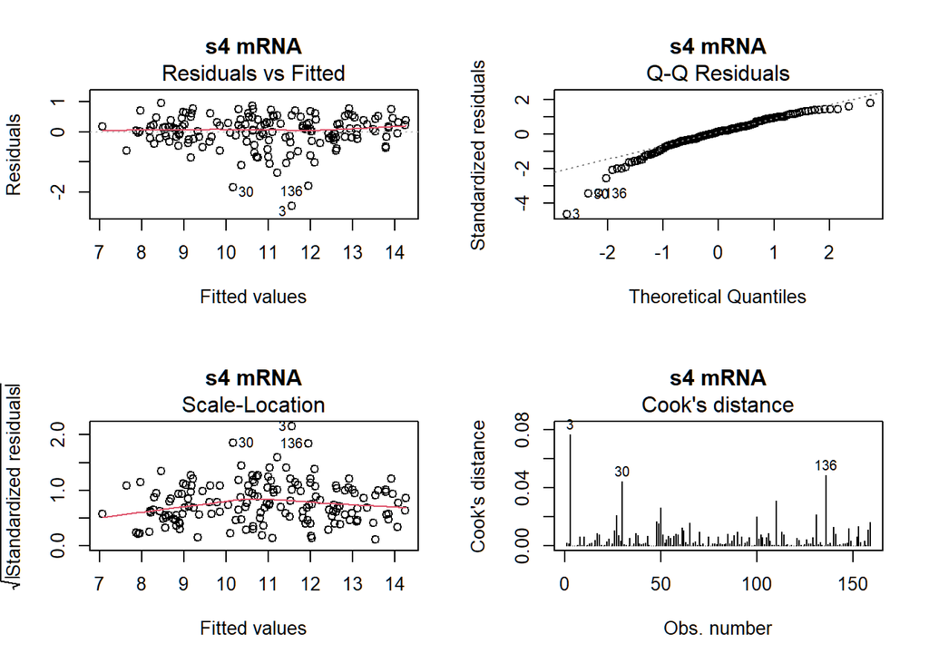

```r
plot(lm_mRNA_s4, which = 1:4, main = "s4 mRNA")
```

```r
# Diagnostic plots for S4 protein model
cat("\nDiagnostics for protein model s4_table:\n")
```

```
##
## Diagnostics for protein model s4_table:
```

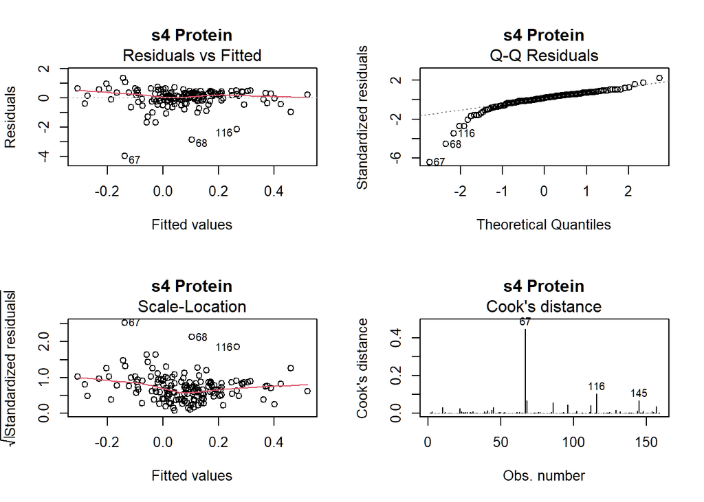

```r
plot(lm_protein_s4, which = 1:4, main = "s4 Protein")
```

```r
par(mfrow = c(1, 1))

# ANOVA to test the significance of the relationship
cat("\nANOVA for mRNA model s3_table:\n")
```

```
##
## ANOVA for mRNA model s3_table:
```

```r
print(anova(lm_mRNA_s3))
```

```
## Analysis of Variance Table
##
## Response: chimp_mrna_mean
##                  Df Sum Sq Mean Sq F value    Pr(>F)
## human_mrna_mean   1 438.93  438.93  1569.4 < 2.2e-16 ***
## Residuals       141  39.43    0.28
## ---
## Signif. codes:  0 '***' 0.001 '**' 0.01 '*' 0.05 '.' 0.1 ' ' 1
```

```r
cat("\nANOVA for protein model s3_table:\n")
```

```
##
## ANOVA for protein model s3_table:
```

```r
print(anova(lm_protein_s3))
```

```
## Analysis of Variance Table
##
## Response: chimp_protein_mean
##                     Df Sum Sq Mean Sq F value    Pr(>F)
## human_protein_mean   1  9.778  9.7780  47.394 1.759e-10 ***
## Residuals          141 29.090  0.2063
## ---
## Signif. codes:  0 '***' 0.001 '**' 0.01 '*' 0.05 '.' 0.1 ' ' 1
```

```r
cat("\nANOVA for mRNA model s4_table:\n")
```

```
##
## ANOVA for mRNA model s4_table:
```

```r
print(anova(lm_mRNA_s4))
```

```
## Analysis of Variance Table
##
## Response: chimp_mrna_mean
##                  Df Sum Sq Mean Sq F value    Pr(>F)
## human_mrna_mean   1 495.56  495.56  1729.8 < 2.2e-16 ***
## Residuals       157  44.98    0.29
## ---
## Signif. codes:  0 '***' 0.001 '**' 0.01 '*' 0.05 '.' 0.1 ' ' 1
```

```r
cat("\nANOVA for protein model s4_table:\n")
```

```
##
## ANOVA for protein model s4_table:
```

```r
print(anova(lm_protein_s4))
```

```
## Analysis of Variance Table
##
## Response: chimp_protein_mean
##                     Df Sum Sq Mean Sq F value   Pr(>F)
## human_protein_mean   1  3.163  3.1628  8.0642 0.005113 **
## Residuals          157 61.576  0.3922
## ---
## Signif. codes:  0 '***' 0.001 '**' 0.01 '*' 0.05 '.' 0.1 ' ' 1
```

Every p-value shows us a statistically significant correlation (P <0.05), where all but the protein model for S4 is highly significant.Our Anova analysis in the mRNA models shows both S3 and S4 showing extremely strong F-statistics (1569.4 and 1729.8 respectively), with corresponding p-values indicating the predictor (human mRNA mean) is a very strong determinant of the response (chimp mRNA mean). In the protein models, the F-statistics are lower (47.394 for S3 and 8.0642 for S4), reflecting the weaker relationships in protein models compared to mRNA models. The significance levels are still strong enough to affirm the relationships despite this.The mRNA models for both samples S3 and S4 exhibit very high R-squared values (approximately 91.7%), indicating excellent fits that explain a significant proportion of the variance in chimp mRNA levels based on human mRNA levels. In contrast, the protein models show much lower R-squared values, with 25.16% for S3 and a mere 4.88% for S4, indicating moderate to poor fits and suggesting that human protein levels are less predictive of chimp protein levels.

## Question 4

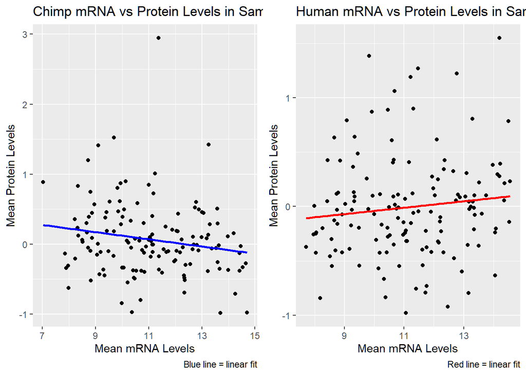

```r
plot_relationships <- function(data, sample_name) {
  # Plot for Chimp
  p1 <- ggplot(data, aes(x = chimp_mrna_mean, y = chimp_protein_mean)) +
    geom_point() +
    geom_smooth(method = "lm", se = FALSE, color = "blue") +
    labs(title = paste("Chimp mRNA vs Protein Levels in", sample_name),
         x = "Mean mRNA Levels",
         y = "Mean Protein Levels",
         caption = "Blue line = linear fit")

  # Plot for Human
  p2 <- ggplot(data, aes(x = human_mrna_mean, y = human_protein_mean)) +
    geom_point() +
    geom_smooth(method = "lm", se = FALSE, color = "red") +
    labs(title = paste("Human mRNA vs Protein Levels in", sample_name),
         x = "Mean mRNA Levels",
         y = "Mean Protein Levels",
         caption = "Red line = linear fit")

    gridExtra::grid.arrange(p1, p2, nrow = 1)
}
plot_relationships(s3_table, "Sample S3")
```

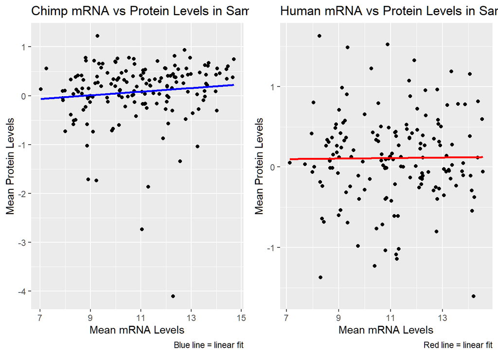

```r
plot_relationships(s4_table, "Sample S4")
```

No real trends are apparent across the plots. mRNA expression levels do not consistently correlate with changes in protein expression for either species in both datasets. These plots also exhibit more outliers and greater variability compared to my earlier plots and analysis.

## Question 5

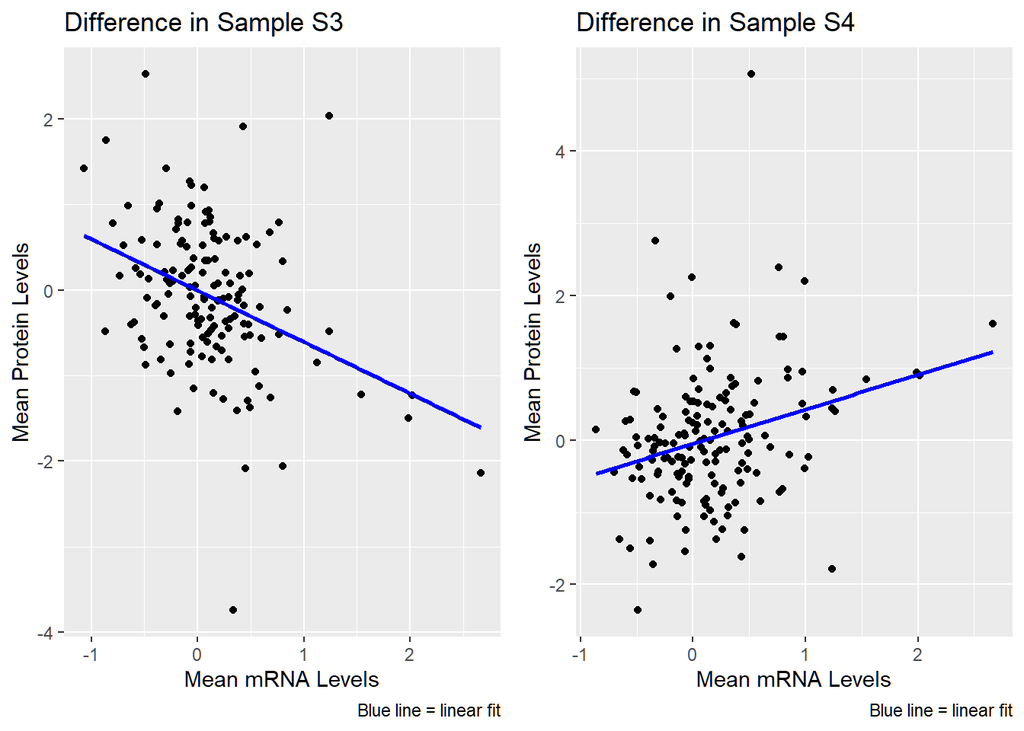

```r
# diffs for s3
s3_table$difference_mrna <- s3_table$human_mrna_mean - s3_table$chimp_mrna_mean
s3_table$difference_protein <- s3_table$human_protein_mean - s3_table$chimp_protein_mean

# diffs for s4
s4_table$difference_mrna <- s4_table$human_mrna_mean - s4_table$chimp_mrna_mean
s4_table$difference_protein <- s4_table$human_protein_mean - s4_table$chimp_protein_mean

plot_differences <- function(data, sample_name) {
  ggplot(data, aes(x = difference_mrna, y = difference_protein)) +
    geom_point() +
    geom_smooth(method = "lm", se = FALSE, color = "blue") +
    labs(title = paste("Difference in", sample_name),
         x = "Mean mRNA Levels",
         y = "Mean Protein Levels",
         caption = "Blue line = linear fit")
}

p1 <- plot_differences(s3_table, "Sample S3")
p2 <- plot_differences(s4_table, "Sample S4")

# Display the plots
library(gridExtra)
grid.arrange(p1, p2, nrow = 1)
```

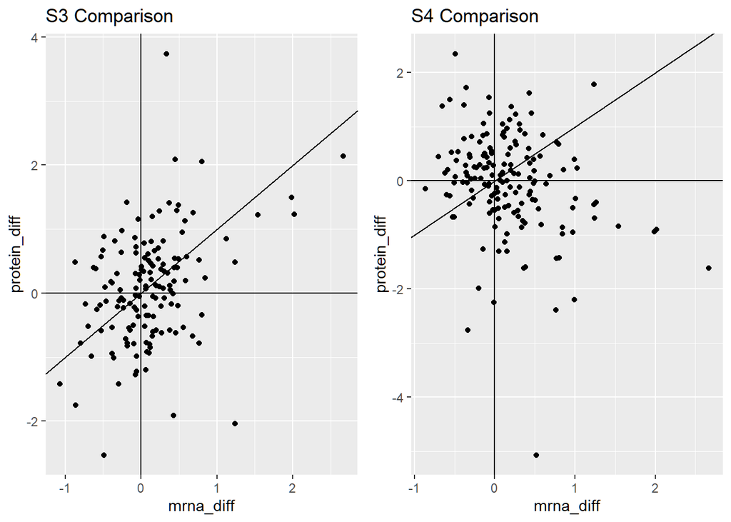

```r
s3_diffs <- s3_means %>%
  reframe(
    mrna_diff = apply(.[,1:2], 1, diff),
    protein_diff = -1 * apply(.[,3:4], 1, diff)
  )

s3_table <- s3_table %>%
  mutate(
    mrna_diff = apply(.[,22:23], 1, diff),
    protein_diff = -1 * apply(.[,24:25], 1, diff)
  )

# Plot
s3_diffs_plot <- ggplot(data = s3_table, aes(x = mrna_diff, y = protein_diff)) +
  geom_point() +
  geom_hline(yintercept = 0) +
  geom_vline(xintercept = 0) +
  geom_abline(intercept = 0, slope = 1) +
  ggtitle("S3 Comparison")

s4_diffs <- s4_means %>%
  reframe(
    mrna_diff = apply(.[,1:2], 1, diff),
    protein_diff = -1 * apply(.[,3:4], 1, diff)
  )

s4_table <- s4_table %>%
  mutate(
    mrna_diff = apply(.[,22:23], 1, diff),
    protein_diff = -1 * apply(.[,24:25], 1, diff)
  )

# Plot
s4_diffs_plot <- ggplot(data = s4_table, aes(x = mrna_diff, y = protein_diff)) +
  geom_point() +
  geom_hline(yintercept = 0) +
  geom_vline(xintercept = 0) +
  geom_abline(intercept = 0, slope = 1) +
  ggtitle("S4 Comparison")

grid.arrange(s3_diffs_plot, s4_diffs_plot, ncol = 2)
```

My results here show a similar result from the S2 figures. The main difference I can see here is that the authors of the original paper may have removed some outliers especially in the S4 comparison, as I see an extreme outlier down around (0.5,-5). The authors do mention using a base 2 logarithmic scale, I wonder if this may condense the plots and produce more similar results true to the original paper.

## Question 6

```r
# Correlation for S3
correlation_s3 <- cor(s3_table$mrna_diff, s3_table$protein_diff, use = "complete.obs")
print(paste("Correlation coefficient for differences between human and chimp protein and mRNA levels in S3:", correlation_s3))
```

```
## [1] "Correlation coefficient for differences between human and chimp protein and mRNA levels in S3: 0.372925205630183"
```

```r
# Correlation for S4
correlation_s4 <- cor(s4_table$mrna_diff, s4_table$protein_diff, use = "complete.obs")
print(paste("Correlation coefficient for differences between human and chimp protein and mRNA levels in S4:", correlation_s4))
```

```
## [1] "Correlation coefficient for differences between human and chimp protein and mRNA levels in S4: -0.274497075393372"
```

The correlation mentioned in the paper are 0.37 for S3 and 0.28 for S4. My correlation values are similar enough in nature to make sense compared to the author’s results, however an interesting thing is that their S4 correlation is positive while mine is negative. They don’t mention explicitly why this is, but it may be an absolute value on their end as their goal is to show the correlation relative to the species and not necessarily care about the “direction” of the correlation.

## Question 7

```r
lm_s3 <- lm(protein_diff ~ mrna_diff, data = s3_table)
lm_s4 <- lm(protein_diff ~ mrna_diff, data = s4_table)

print("Summary of linear model for S3:")
```

```
## [1] "Summary of linear model for S3:"
```

```r
print(summary(lm_s3))
```

```
##
## Call:
## lm(formula = protein_diff ~ mrna_diff, data = s3_table)
##
## Residuals:
##     Min      1Q  Median      3Q     Max
## -2.7887 -0.4606  0.0292  0.4105  3.5315
##
## Coefficients:
##             Estimate Std. Error t value Pr(>|t|)
## (Intercept) 0.004693   0.068513   0.069    0.945
## mrna_diff   0.601922   0.126122   4.773  4.5e-06 ***
## ---
## Signif. codes:  0 '***' 0.001 '**' 0.01 '*' 0.05 '.' 0.1 ' ' 1
##
## Residual standard error: 0.8008 on 141 degrees of freedom
## Multiple R-squared:  0.1391, Adjusted R-squared:  0.133
## F-statistic: 22.78 on 1 and 141 DF,  p-value: 4.497e-06
```

```r
print("Summary of linear model for S4:")
```

```
## [1] "Summary of linear model for S4:"
```

```r
print(summary(lm_s4))
```

```
##
## Call:
## lm(formula = protein_diff ~ mrna_diff, data = s4_table)
##
## Residuals:
##     Min      1Q  Median      3Q     Max
## -4.8717 -0.4446  0.0219  0.5353  2.3230
##
## Coefficients:
##             Estimate Std. Error t value Pr(>|t|)
## (Intercept)  0.05150    0.07511   0.686 0.493979
## mrna_diff   -0.47737    0.13346  -3.577 0.000463 ***
## ---
## Signif. codes:  0 '***' 0.001 '**' 0.01 '*' 0.05 '.' 0.1 ' ' 1
##
## Residual standard error: 0.9004 on 157 degrees of freedom
## Multiple R-squared:  0.07535,    Adjusted R-squared:  0.06946
## F-statistic: 12.79 on 1 and 157 DF,  p-value: 0.0004627
```

```r
# ANOVA
print("ANOVA for the linear model of S3:")
```

```
## [1] "ANOVA for the linear model of S3:"
```

```r
print(anova(lm_s3))
```

```
## Analysis of Variance Table
##
## Response: protein_diff
##            Df Sum Sq Mean Sq F value    Pr(>F)
## mrna_diff   1 14.608 14.6081  22.777 4.497e-06 ***
## Residuals 141 90.431  0.6414
## ---
## Signif. codes:  0 '***' 0.001 '**' 0.01 '*' 0.05 '.' 0.1 ' ' 1
```

```r
print("ANOVA for the linear model of S4:")
```

```
## [1] "ANOVA for the linear model of S4:"
```

```r
print(anova(lm_s4))
```

```
## Analysis of Variance Table
##
## Response: protein_diff
##            Df  Sum Sq Mean Sq F value    Pr(>F)
## mrna_diff   1  10.372 10.3719  12.794 0.0004627 ***
## Residuals 157 127.280  0.8107
## ---
## Signif. codes:  0 '***' 0.001 '**' 0.01 '*' 0.05 '.' 0.1 ' ' 1
```

```r
# Plot Diagnostics
par(mfrow = c(2, 2))

cat("\nDiagnostics for s3:\n")
```

```
##
## Diagnostics for s3:
```

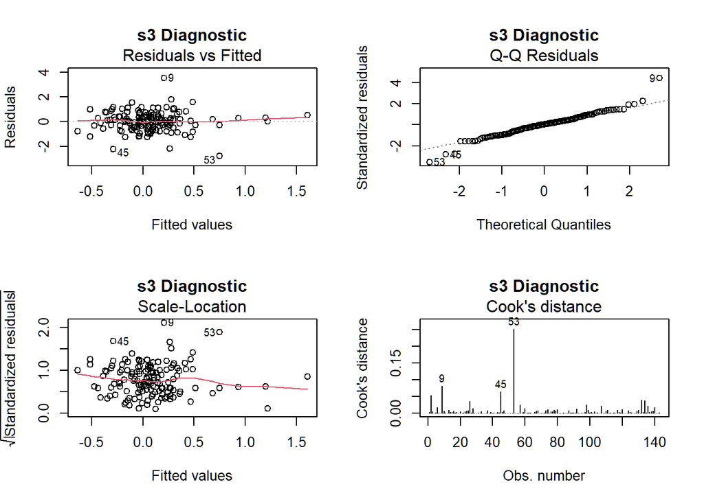

```r
plot(lm_s3, which = 1:4, main = "s3 Diagnostic")
```

```r
par(mfrow = c(1, 1))

par(mfrow = c(2, 2))

cat("\nDiagnostics for s4:\n")
```

```
##
## Diagnostics for s4:
```

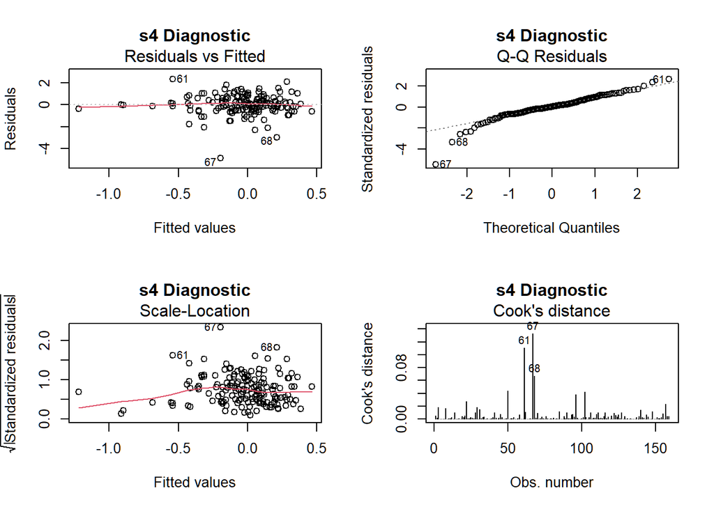

```r
plot(lm_s4, which = 1:4, main = "s4 Diagnostic")
```

```r
par(mfrow = c(1, 1))
```

For the S3 sample, there is a significant positive relationship, with a coefficient of 0.6019 indicating that increases in mRNA differences are associated with increases in protein differences (p-value = 4.5e-06). This model explains about 13.91% of the variance in protein differences, as indicated by the R-squared value. The ANOVA results reinforce this significant relationship with an F-statistic of 22.78. The S4 sample exhibits a significant negative relationship between mRNA and protein differences, with a coefficient of -0.4774 (p-value = 0.000463), but this model has a lower explanatory power with an R-squared of 7.535%. The negative coefficient implies that increases in mRNA differences correspond to decreases in protein differences, a reversal of the trend observed in the S3 sample. The ANOVA for S4 confirms the significance of the relationship, with an F-statistic of 12.79.

## Question 8

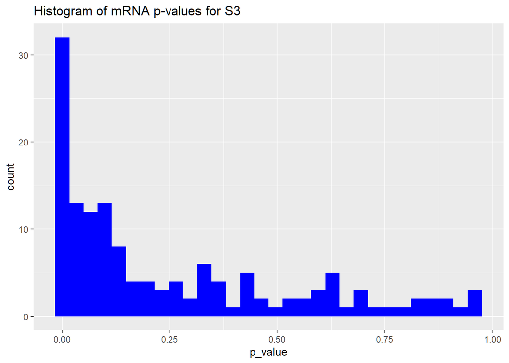

```r
# t-test function
t.test.hc <- function(human_data, chimp_data, var.equal = TRUE) {
  t.test(human_data, chimp_data, var.equal = var.equal)$p.value
}

# Set indices and vectors for pvals
human_mRNA_indices <- 10:15
chimp_mRNA_indices <- 4:9
human_protein_indices <- 19:21
chimp_protein_indices <- 16:18

p_values_mRNA_s3 <- vector("numeric", nrow(s3_table))
p_values_protein_s3 <- vector("numeric", nrow(s3_table))
p_values_mRNA_s4 <- vector("numeric", nrow(s4_table))
p_values_protein_s4 <- vector("numeric", nrow(s4_table))

# t-tests for s3_table
for (i in seq_len(nrow(s3_table))) {
  p_values_mRNA_s3[i] <- t.test.hc(s3_table[i, human_mRNA_indices], s3_table[i, chimp_mRNA_indices])
  p_values_protein_s3[i] <- t.test.hc(s3_table[i, human_protein_indices], s3_table[i, chimp_protein_indices])
}

# t-tests for s4_table
for (i in seq_len(nrow(s4_table))) {
  p_values_mRNA_s4[i] <- t.test.hc(s4_table[i, human_mRNA_indices], s4_table[i, chimp_mRNA_indices])
  p_values_protein_s4[i] <- t.test.hc(s4_table[i, human_protein_indices], s4_table[i, chimp_protein_indices])
}


# S3 histograms
ggplot(data.frame(p_value = p_values_mRNA_s3), aes(x = p_value)) +
  geom_histogram(bins = 30, fill = "blue") +
  ggtitle("Histogram of mRNA p-values for S3")
```

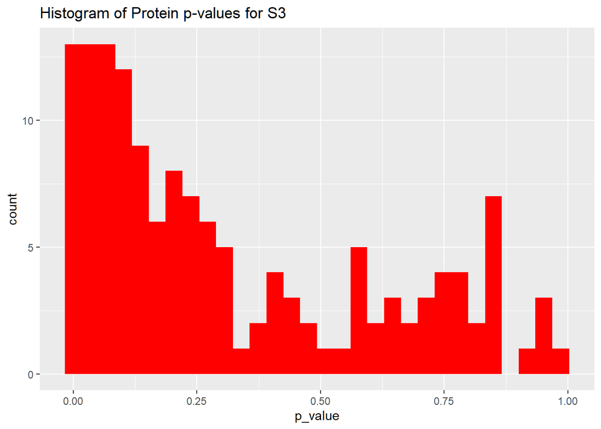

```r
ggplot(data.frame(p_value = p_values_protein_s3), aes(x = p_value)) +
  geom_histogram(bins = 30, fill = "red") +
  ggtitle("Histogram of Protein p-values for S3")
```

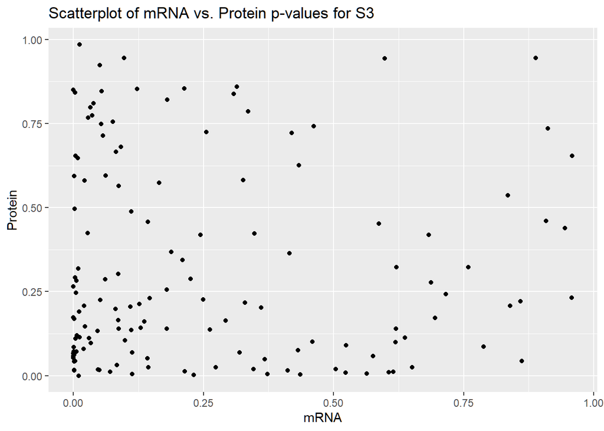

```r
# S3 scatterplot
ggplot(data.frame(mRNA = p_values_mRNA_s3, Protein = p_values_protein_s3), aes(x = mRNA, y = Protein)) +
  geom_point() +
  ggtitle("Scatterplot of mRNA vs. Protein p-values for S3")
```

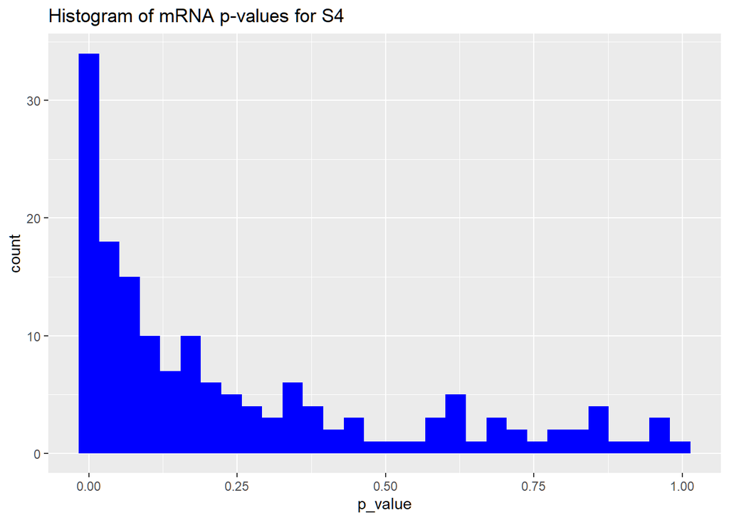

```r
# S4 histograms
ggplot(data.frame(p_value = p_values_mRNA_s4), aes(x = p_value)) +
  geom_histogram(bins = 30, fill = "blue") +
  ggtitle("Histogram of mRNA p-values for S4")
```

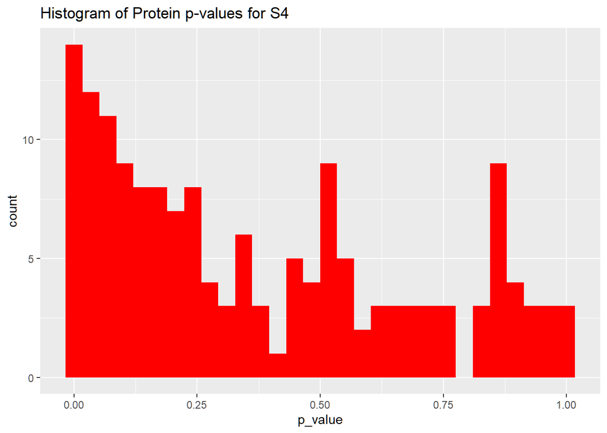

```r
ggplot(data.frame(p_value = p_values_protein_s4), aes(x = p_value)) +
  geom_histogram(bins = 30, fill = "red") +
  ggtitle("Histogram of Protein p-values for S4")
```

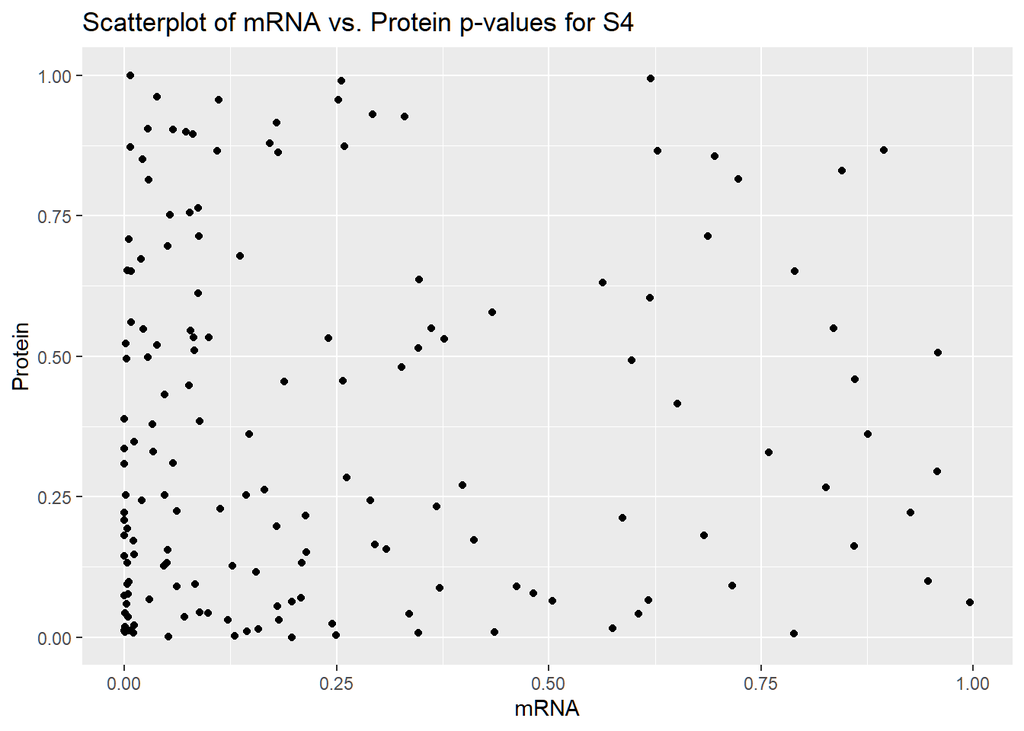

```r
# S4 scatterplot
ggplot(data.frame(mRNA = p_values_mRNA_s4, Protein = p_values_protein_s4), aes(x = mRNA, y = Protein)) +
  geom_point() +
  ggtitle("Scatterplot of mRNA vs. Protein p-values for S4")
```

```r
# Summaries of significant p values (<0.05)
significant_mRNA_s3 <- sum(p_values_mRNA_s3 < 0.05)
significant_protein_s3 <- sum(p_values_protein_s3 < 0.05)
significant_mRNA_s4 <- sum(p_values_mRNA_s4 < 0.05)
significant_protein_s4 <- sum(p_values_protein_s4 < 0.05)

print(paste("Number of significant mRNA differences in S3 at p < 0.05:", significant_mRNA_s3))
```

```
## [1] "Number of significant mRNA differences in S3 at p < 0.05: 45"
```

```r
print(paste("Number of significant protein differences in S3 at p < 0.05:", significant_protein_s3))
```

```
## [1] "Number of significant protein differences in S3 at p < 0.05: 26"
```

```r
print(paste("Number of significant mRNA differences in S4 at p < 0.05:", significant_mRNA_s4))
```

```
## [1] "Number of significant mRNA differences in S4 at p < 0.05: 49"
```

```r
print(paste("Number of significant protein differences in S4 at p < 0.05:", significant_protein_s4))
```

```
## [1] "Number of significant protein differences in S4 at p < 0.05: 26"
```

The results indicate a notable level of differential expression between humans and chimps for both mRNA and protein levels, with a higher number of significant differences observed in mRNA than in protein across both samples, S3 and S4.

S3 Sample: There were 45 significant mRNA differences and 26 significant protein differences. This suggests that transcriptional differences between the species are more pronounced or detectable than translational differences in this particular sample. The larger number of significant mRNA differences could indicate that many regulatory or gene expression changes at the mRNA level may not translate directly into protein level differences, possibly due to post-transcriptional regulatory mechanisms.

S4 Sample: Similar to S3, there were 49 significant mRNA differences, indicating a slightly higher variability or response at the genetic transcription level compared to S3. The number of significant protein differences remains the same as in S3, at 26. This consistency in protein differences, despite a slight increase in mRNA differences, further supports the idea that not all changes at the mRNA level have a corresponding impact at the protein level.

## Question 9

```r
#human_mRNAs <- 10:15
#chimp_mRNAs <- 4:9
#human_proteins <- 19:21
#chimp_proteins <- 16:18

# Vectors for storing p
p_values_ttest_mRNA_s3 <- numeric(nrow(s3_table))
p_values_anova_mRNA_s3 <- numeric(nrow(s3_table))
p_values_ttest_protein_s3 <- numeric(nrow(s3_table))
p_values_anova_protein_s3 <- numeric(nrow(s3_table))

# T-test with no variance
t_test_novar <- function(x, y) {
  t.test(x = x, y = y,
         alternative = "two.sided",
         var.equal = FALSE,
         conf.level = 0.95)$p.value
}

s3_table <- s3_table %>%
  mutate(
    mrna_pval_nev = apply(s3_table[,4:9], 1, FUN = t_test_novar,
                          y = s3_table[,10:15]),
    protein_pval_nev = apply(s3_table[,16:18], 1, FUN = t_test_novar,
                           y = s3_table[,19:21])
  )

s4_table <- s4_table %>%
  mutate(
    mrna_pval_nev = apply(s4_table[,4:9], 1, FUN = t_test_novar,
                          y = s4_table[,10:15]),
    protein_pval_nev = apply(s4_table[,16:18], 1, FUN = t_test_novar,
                           y = s4_table[,19:21])
  )

mrna_nev_s3 <- s3_table %>%
  filter(mrna_pval_nev < 0.05) %>%
  count()
protein_nev_s3 <- s3_table %>%
  filter(protein_pval_nev < 0.05) %>%
  count()

mrna_nev_s4 <- s4_table %>%
  filter(mrna_pval_nev < 0.05) %>%
  count()
mrna_nev_s4 <- s4_table %>%
  filter(protein_pval_nev < 0.05) %>%
  count()

nev_both <- data.frame(mrna_nev_s3, protein_nev_s3, mrna_nev_s4, mrna_nev_s4)
names(nev_both) <- c('MRNA_NEV_s3','Protein_NEV_s3','MRNA_NEV_s4','Protein_NEV_s4')
nev_both
```

```
##   MRNA_NEV_s3 Protein_NEV_s3 MRNA_NEV_s4 Protein_NEV_s4
## 1         117             18          14             14
```

```r
lin_s3 <- lm(formula = s3_table$mrna_diff ~ s3_table$protein_diff, data = s3_table)
lin_s3
```

```
##
## Call:
## lm(formula = s3_table$mrna_diff ~ s3_table$protein_diff, data = s3_table)
##
## Coefficients:
##           (Intercept)  s3_table$protein_diff
##                0.0976                 0.2310
```

```r
anova(lin_s3)
```

```
## Analysis of Variance Table
##
## Response: s3_table$mrna_diff
##                        Df Sum Sq Mean Sq F value    Pr(>F)
## s3_table$protein_diff   1  5.607  5.6074  22.777 4.497e-06 ***
## Residuals             141 34.712  0.2462
## ---
## Signif. codes:  0 '***' 0.001 '**' 0.01 '*' 0.05 '.' 0.1 ' ' 1
```

```r
lin_s4 <- lm(formula = s4_table$mrna_diff ~ s4_table$protein_diff, data = s4_table)
lin_s4
```

```
##
## Call:
## lm(formula = s4_table$mrna_diff ~ s4_table$protein_diff, data = s4_table)
##
## Coefficients:
##           (Intercept)  s4_table$protein_diff
##                0.1695                -0.1578
```

```r
anova(lin_s4)
```

```
## Analysis of Variance Table
##
## Response: s4_table$mrna_diff
##                        Df Sum Sq Mean Sq F value    Pr(>F)
## s4_table$protein_diff   1  3.429  3.4294  12.794 0.0004627 ***
## Residuals             157 42.084  0.2681
## ---
## Signif. codes:  0 '***' 0.001 '**' 0.01 '*' 0.05 '.' 0.1 ' ' 1
```

Old equal variance pval counts: Number of significant mRNA differences in S3 at p < 0.05: 45 Number of significant protein differences in S3 at p < 0.05: 26 Number of significant mRNA differences in S4 at p < 0.05: 49 Number of significant protein differences in S4 at p < 0.05: 26

## Question 10

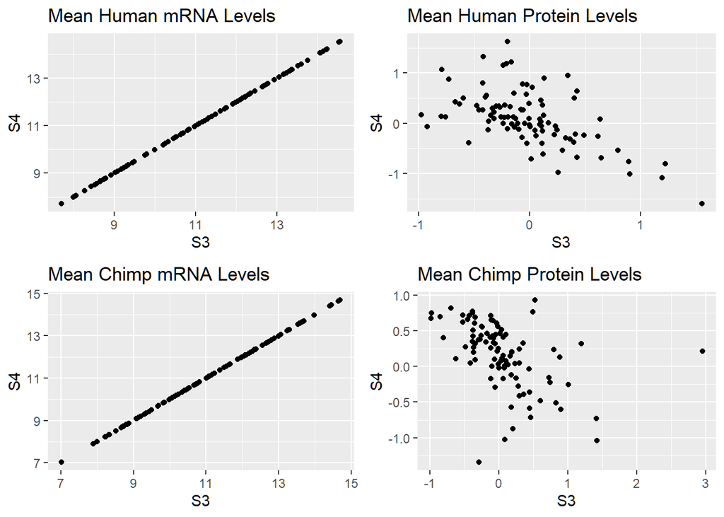

```r
common_genes <- intersect(s3_table$refseq_id, s4_table$refseq_id)
# Filter for only the common genes and merge
s3_common <- s3_table[s3_table$refseq_id %in% common_genes, ]
s4_common <- s4_table[s4_table$refseq_id %in% common_genes, ]
merged_data <- merge(s3_common, s4_common, by = "refseq_id", suffixes = c("_s3", "_s4"))


# Plot mean human mRNA levels
mhm <- ggplot(merged_data, aes(x = human_mrna_mean_s3, y = human_mrna_mean_s4)) +
  geom_point() +
  labs(title = "Mean Human mRNA Levels",
       x = "S3",
       y = "S4")

# Plot mean human protein levels
mhp <- ggplot(merged_data, aes(x = human_protein_mean_s3, y = human_protein_mean_s4)) +
  geom_point() +
  labs(title = "Mean Human Protein Levels",
       x = "S3",
       y = "S4")

# Plot mean chimp mRNA levels
mcm <- ggplot(merged_data, aes(x = chimp_mrna_mean_s3, y = chimp_mrna_mean_s4)) +
  geom_point() +
  labs(title = "Mean Chimp mRNA Levels",
       x = "S3",
       y = "S4")

# Plot mean chimp protein levels
mcp <- ggplot(merged_data, aes(x = chimp_protein_mean_s3, y = chimp_protein_mean_s4)) +
  geom_point() +
  labs(title = "Mean Chimp Protein Levels",
       x = "S3",
       y = "S4")

grid.arrange(mhm, mhp, mcm, mcp, ncol = 2, nrow = 2)
```

It would make sense that the mRNA levels are almost directly correlated. Since it is essentially comparing a subset of a genome, we’d expect these species to have similar mRNA across samples. The same can’t be said for proteins expression, however, as we know that expression levels vary vastly from sample to sample, which is what essentially differentiates one subject from another.

Jiang, D., Cope, A. L., Zhang, J., & Pennell, M. (2023). On the Decoupling of Evolutionary Changes in mRNA and Protein Levels. Molecular biology and evolution, 40(8), msad169. https://doi.org/10.1093/molbev/msad169

## Question 11

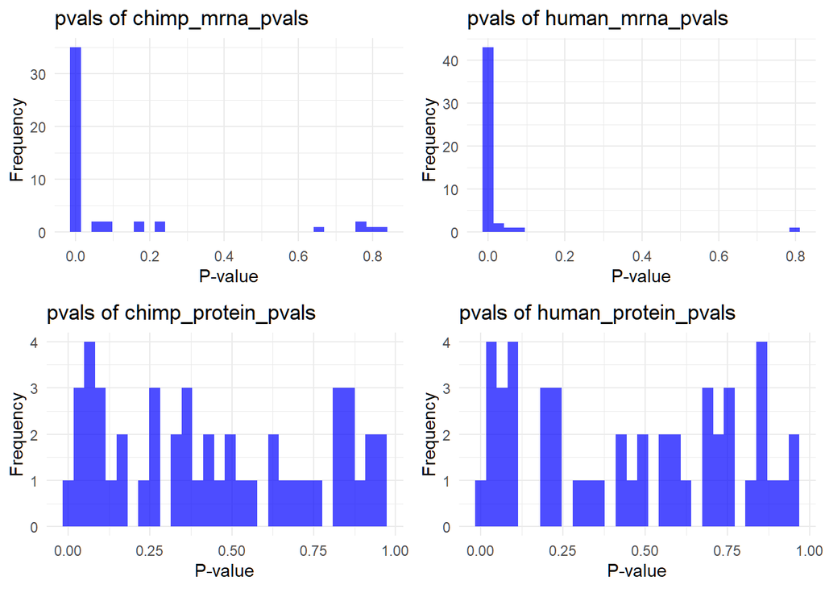

```r
# t-test func
paired_t_test <- function(index, data_s3, data_s4) {
  data1 <- as.numeric(data_s3[index, ])
  data2 <- as.numeric(data_s4[index, ])
  # Check if there are enough non-NA observations
  if (sum(!is.na(data1) & !is.na(data2)) < 2) {
    return(NA)  # Return NA if not enough observations
  }
  # Perform the t-test
  p_value <- t.test(data1, data2, paired = TRUE, var.equal = TRUE)$p.value
  return(p_value)
}

# Resamples
s3_resample <- bootstraps(s3_table, times = 4)
s3_sample <- assessment(s3_resample$splits[[2]])
s3_sample <- s3_sample[1:50,] # take subset to ensure no oob errors

s4_resample <- bootstraps(s4_table, times = 4)
s4_sample <- assessment(s4_resample$splits[[2]])
s4_sample <- s4_sample[1:50,] # take subset to ensure no oob errors

# Perform t-tests
indices <- seq_len(nrow(s3_sample))  # Ensure s3_sample and s4_sample have the same number of rows

pvals <- s3_sample %>%
  reframe(
    chimp_mrna_pvals = sapply(indices, paired_t_test, data_s3 = s3_sample[, 4:9], data_s4 = s4_sample[, 4:9]),
    human_mrna_pvals = sapply(indices, paired_t_test, data_s3 = s3_sample[, 10:15], data_s4 = s4_sample[, 10:15]),
    chimp_protein_pvals = sapply(indices, paired_t_test, data_s3 = s3_sample[, 16:18], data_s4 = s4_sample[, 16:18]),
    human_protein_pvals = sapply(indices, paired_t_test, data_s3 = s3_sample[, 19:21], data_s4 = s4_sample[, 19:21])
  )

# Set up for plotting
pvals_long <- pvals %>%
  pivot_longer(
    everything(),
    names_to = "measurement_type",
    values_to = "p_value"
  )
# Function to plot histograms
create_histogram <- function(data, measurement_type) {
  ggplot(data %>% filter(measurement_type == !!measurement_type), aes(x = p_value)) +
    geom_histogram(bins = 30, fill = "blue", alpha = 0.7) +
    labs(title = paste("pvals of", measurement_type),
         x = "P-value",
         y = "Frequency") +
    theme_minimal()
}

# Create histograms for each measurement type
hist_chimp_mrna <- create_histogram(pvals_long, "chimp_mrna_pvals")
hist_human_mrna <- create_histogram(pvals_long, "human_mrna_pvals")
hist_chimp_protein <- create_histogram(pvals_long, "chimp_protein_pvals")
hist_human_protein <- create_histogram(pvals_long, "human_protein_pvals")

grid.arrange(hist_chimp_mrna, hist_human_mrna, hist_chimp_protein, hist_human_protein, ncol = 2, nrow = 2)
```

Like the other p-value data I analyzed, the mRNA results in both datasets showed a higher occurrence of significant p-values. Conversely, the protein data exhibited a more dispersed distribution of p-values, with fewer instances of significance. Notably, significant p-values were more prevalent in the mRNA data when comparing humans and chimps.

## Question 12

### A

```r
data("ALL")
p_data <- pData(ALL)
g_data <- exprs(ALL)

fusiondf <- data.frame(fusionprotein = p_data[,"fusion protein"],gene_1970s = g_data["1970_s_at",])
fusion_table <- table(fusiondf$fusionprotein)

lm_gene_protein <- lm(formula = gene_1970s ~ fusionprotein, data = fusiondf)
anova(lm_gene_protein)
```

```
## Analysis of Variance Table
##
## Response: gene_1970s
##               Df  Sum Sq Mean Sq F value    Pr(>F)
## fusionprotein  2 0.92909 0.46455  19.095 4.477e-06 ***
## Residuals     30 0.72984 0.02433
## ---
## Signif. codes:  0 '***' 0.001 '**' 0.01 '*' 0.05 '.' 0.1 ' ' 1
```

```r
lm_noint <- lm(formula = gene_1970s ~ fusionprotein + 0, data = fusiondf)

lm_noint
```

```
##
## Call:
## lm(formula = gene_1970s ~ fusionprotein + 0, data = fusiondf)
##
## Coefficients:
##      fusionproteinp190  fusionproteinp190/p210       fusionproteinp210
##                  3.705                   4.067                   4.011
```

I can now see we have the means for each category of fusionproteinp190 fusionproteinp190/p210 fusionproteinp210  
3.705 4.067 4.011

```r
anova(lm_noint)
```

```
## Analysis of Variance Table
##
## Response: gene_1970s
##               Df Sum Sq Mean Sq F value    Pr(>F)
## fusionprotein  3 494.38 164.793  6773.7 < 2.2e-16 ***
## Residuals     30   0.73   0.024
## ---
## Signif. codes:  0 '***' 0.001 '**' 0.01 '*' 0.05 '.' 0.1 ' ' 1
```

```r
fusionproteinp190_mean <- summary(lm_noint)$coefficients[1,1]
fusionproteinp190_p210_mean <- summary(lm_noint)$coefficients[2,1]
fusionproteinp210_mean <- summary(lm_noint)$coefficients[3,1]
fp_mean <- mean(fusiondf$gene_1970s[!is.na(fusiondf$fusionprotein)])

# Print the values
print(paste("Mean coefficient for fusion protein p190:", fusionproteinp190_mean))
```

```
## [1] "Mean coefficient for fusion protein p190: 3.70523030673632"
```

```r
print(paste("Mean coefficient for fusion protein p190_p210:", fusionproteinp190_p210_mean))
```

```
## [1] "Mean coefficient for fusion protein p190_p210: 4.06667114316939"
```

```r
print(paste("Mean coefficient for fusion protein p210:", fusionproteinp210_mean))
```

```
## [1] "Mean coefficient for fusion protein p210: 4.01072988361328"
```

```r
print(paste("Mean of gene expression for all fps:", fp_mean))
```

```
## [1] "Mean of gene expression for all fps: 3.86691283117511"
```

### B

```r
p190 <- fusiondf %>% filter(fusionprotein == "p190")
p210 <- fusiondf %>% filter(fusionprotein == "p210")
p190_210 <- fusiondf %>% filter(fusionprotein == "p190/p210")

t.test(x = p190$gene_1970s,
       y = p210$gene_1970s,
       alternative = "two.sided", var.equal = TRUE)
```

```
##
##  Two Sample t-test
##
## data:  p190$gene_1970s and p210$gene_1970s
## t = -4.7158, df = 23, p-value = 9.453e-05
## alternative hypothesis: true difference in means is not equal to 0
## 95 percent confidence interval:
##  -0.4395126 -0.1714866
## sample estimates:
## mean of x mean of y
##   3.70523   4.01073
```

We can see here that the sample estimates line up with our coefficients calculated before and that there is a statistically significant pvalue for both (even if they are different), but this is because ANOVA can compare more than two groups and tests if at least one group mean is different, while the t-test directly tests the difference between two specific groups.

### C

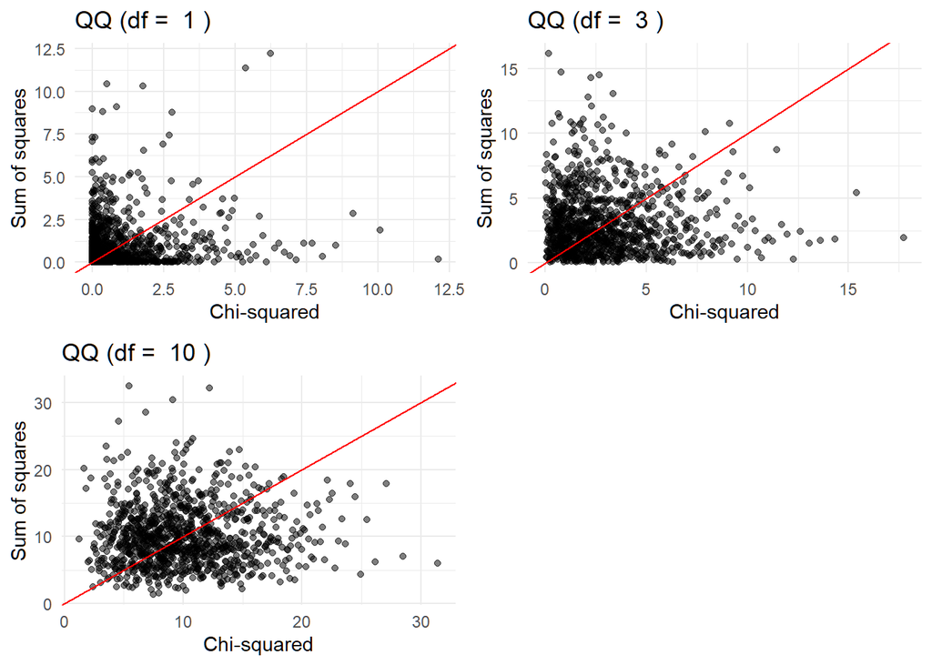

```r
n_sim <- 1000  # Number of simulations
set.seed(42)

# Define the number of squared normal variables
ns <- c(1, 3, 10)

plots <- list()

for (n in ns) {
    # Simulate n_sim instances of n normal variables
    norm_matrix <- matrix(rnorm(n_sim * n), nrow = n_sim, ncol = n)

    # Square all elements of the matrix and sum rows
    chi_sums <- rowSums(norm_matrix^2)

    # Generate chi-squared variables directly
    chi_vars <- rchisq(n_sim, df = n)

    # Prepare data for plotting
    qq_data <- data.frame(Empirical = chi_sums, Theoretical = qchisq(ppoints(n_sim), df = n))

    # Create QQ plot
    p <- ggplot(qq_data, aes(x = Theoretical, y = Empirical)) +
        geom_point(alpha = 0.5) +  # Use points to plot the actual quantiles
        geom_abline(slope = 1, intercept = 0, col = "red") +  # Ideal line y = x
        labs(title = paste("QQ (df = ", n, ")"),
             x = "Chi-squared",
             y = "Sum of squares") +
        theme_minimal()

    # Store the plot in the list
    plots[[paste("n=", n)]] <- p
}

do.call(grid.arrange, c(plots, ncol = 2))
```

### D

```r
rs_df <- data.frame(sex = p_data$sex, remission = p_data$remission)
rs_table <- table(rs_df)

rs_chi <- chisq.test(rs_table, correct = F)
crc_total <- sum(rs_table[,1]) #cr col
rc_total <- sum(rs_table[,2]) # ref col
mr_total <- sum(rs_table[2,]) # male row
fr_total <- sum(rs_table[1,]) # female row
full_total <- sum(crc_total, rc_total)

e_crm <- crc_total*mr_total/full_total
e_crf <- crc_total*fr_total/full_total
e_refm <- rc_total*mr_total/full_total
e_reff <- rc_total*fr_total/full_total


# From the chi square test expected values
rs_chi$expected
```

```
##    remission
## sex       CR       REF
##   F 29.48673  4.513274
##   M 68.51327 10.486726
```

```r
print(paste("Expected count for CRM:", e_crm))
```

```
## [1] "Expected count for CRM: 68.5132743362832"
```

```r
print(paste("Expected count for CRF:", e_crf))
```

```
## [1] "Expected count for CRF: 29.4867256637168"
```

```r
print(paste("Expected count for REFM:", e_refm))
```

```
## [1] "Expected count for REFM: 10.4867256637168"
```

```r
print(paste("Expected count for REFF:", e_reff))
```

```
## [1] "Expected count for REFF: 4.51327433628319"
```